# Local elections in Madrid - 2015

Daniel Almazan

**[Versión en español](https://danielalmazan.com/elections/elections_locals_2015_madrid_es.html)**

[back to elections](https://danielalmazan.com/elections/)

### About

This project studies the results of the 2015 local elections in Madrid, Spain. It focuses on vote share of the four main parties (PP, Ahora Madrid, PSOE and Ciudadanos) and the potential connection with turnout levels and median household income. The analysis has been done at the most detailed level possible, in this case the census section, of which there are more than 2,000 in Madrid.

### Votes to parties and left-right split

**[This map](https://danielalmazan.com/elections/madrid_elections_2015_win.html)** shows the results of the local elections in Madrid, with the most voted party in each section and the vote share of 8 different parties. The vote split between left-wing and right-wing parties is also shown (*have a look, it’s cool!*).

### Results of the main four parties

The map below shows the vote share obtained by each of the four main parties in the 2015 local elections in Madrid. The geographic distribution of results for PP, Ahora Madrid, PSOE and Ciudadanos is quite different and can be explored in detail in the map.

[interactive chart not shown]

### Distribution of voter turnout and most voted party per area

The map below shows the abstention/turnout levels in each of the census sections of Madrid, as well as the party that obtained the largest number of votes in those sections.

[interactive chart not shown]

### Vote share by party in relation to turnout and median household income

The following plot shows the relation between voter turnout and vote share of the four main parties for each of the census sections in Madrid. As it can be seen, there is a different pattern for left and right-wing parties. While Ahora Madrid and (especially) PSOE obtain better results in those sections with voter turnout below average (68.9%), right-wing parties (PP and Ciudadanos) tend to obtain better results in those sections with higher voter turnout.

This pattern is especially clear with PSOE and PP, while the vote share for Ahora Madrid is quite constant for sections with turnout lower than 65%, dropping after that.

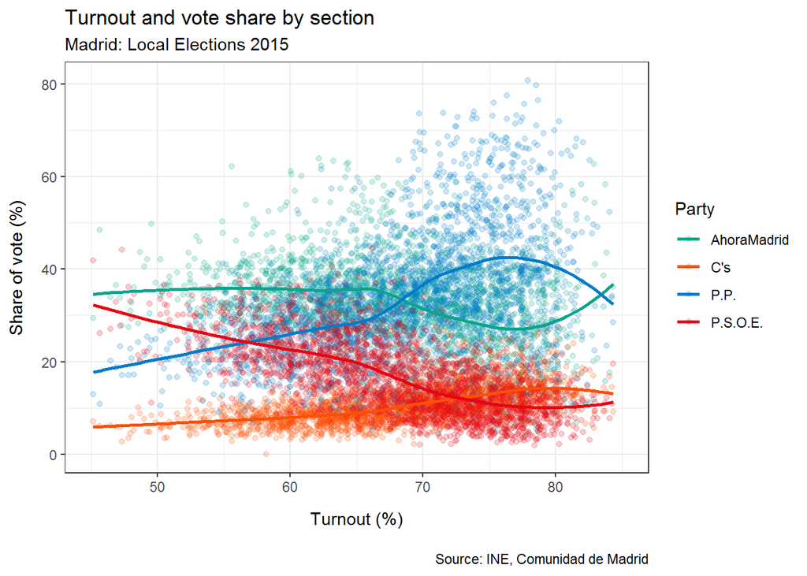

Although no household income data is available for census sections, data from the Urban Audit provides information about Sub-City districts. These areas are formed by aggregation of census sections and have similar sizes to the *barrios* (neighbourhoods) in Madrid. For the purposes of this project, each census section has been assigned the median income of the Sub-City Distric they belong to.

The plot below shows the relation between median annual household income and vote share of the four main parties in the elections. It is clear that left-wing parties obtain better results in those areas with lower incomes and their support decreases in wealthier areas. On the other hand, right-wing parties, especially PP, obtain a lower vote share in poorer areas and their support increases when the income is higher.

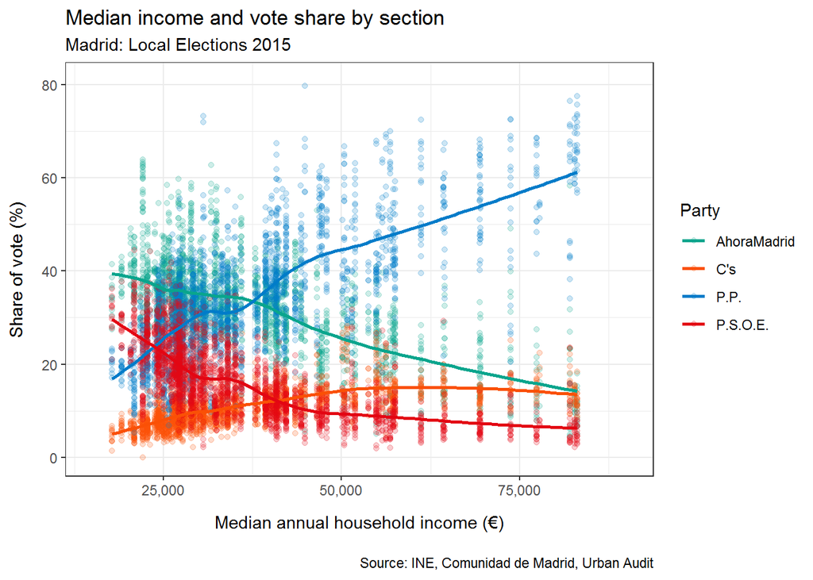

### Turnout and income

After having observed a reasonable level of correlation between vote share and both turnout and median household income, with vote to right-wing parties potentially having a positive correlation with those two variables and vote to left-wing parties experiencing the opposite, it could be interesting to observe the relation between voter turnout and median household income.

The plot below shows each census section in Madrid, with the voter turnout in the local elections and the median annual household income of the Sub-City Distric that each section belongs to. The dots are coloured with the most voted party in the section.

It can be seen that the correlation is weaker here, although it is clear that most areas with high incomes have turnout levels higher than the average. It is also clear that sections with low turnouts are generally in less wealthy areas. However, the correlation does not go both ways, as there is a great variability in terms of voter turnout in areas with low median incomes.

What can also be seen here is the predominance of PP in the wealthiest areas, with Ahora Madrid winning most of the sections in poorer areas.

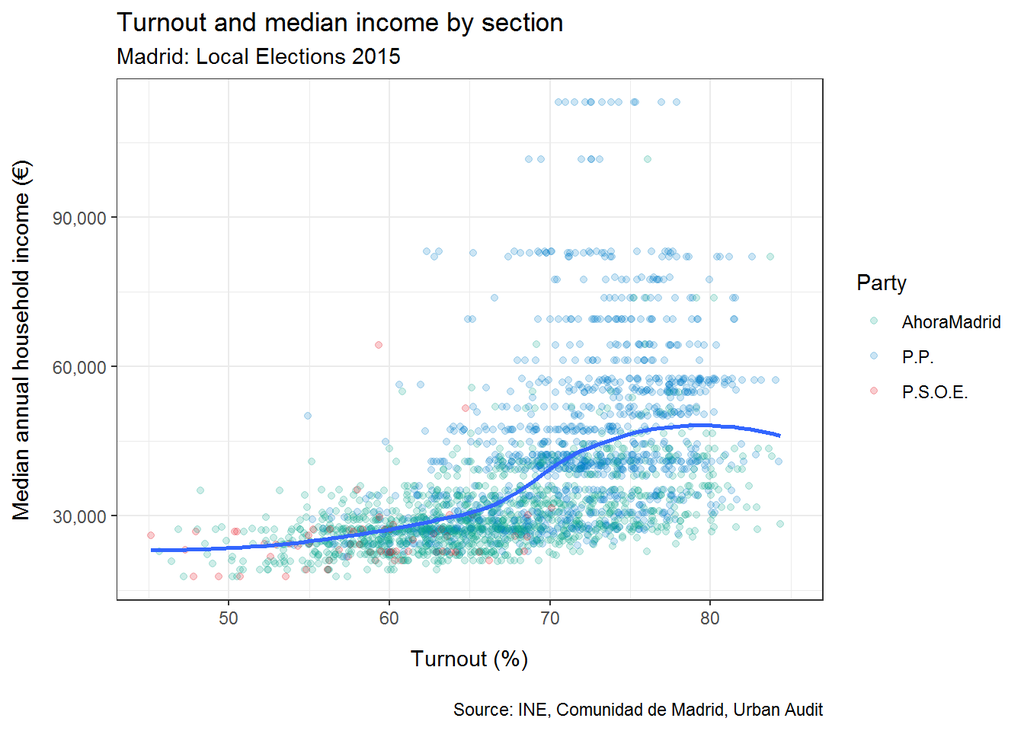

[back to elections](https://danielalmazan.com/elections/)